# Lab5 Daniel Kwong

https://github.com/daniellkwong/GSB544.git

## Part One: Data Exploration

```python
import pandas as pd

myData = pd.read_csv("https://www.dropbox.com/s/bocjjyo1ehr5auz/insurance_costs_1.csv?dl=1")

myData.head()
```

|  | age | sex | bmi | smoker | region | charges |
| --- | --- | --- | --- | --- | --- | --- |
| 0 | 19 | female | 27.900 | yes | southwest | 16884.92400 |
| 1 | 33 | male | 22.705 | no | northwest | 21984.47061 |
| 2 | 32 | male | 28.880 | no | northwest | 3866.85520 |
| 3 | 31 | female | 25.740 | no | southeast | 3756.62160 |
| 4 | 60 | female | 25.840 | no | northwest | 28923.13692 |

```python
myDataDummies = pd.get_dummies(myData, columns = ["region", "sex"], drop_first=True)
cols = ["region_northwest", "region_southeast", "region_southwest", "sex_male"]
myDataDummies[cols] = myDataDummies[cols].astype(int)
myDataDummies["smoker"] = myDataDummies["smoker"].map({"yes": 1, "no": 0})

myDataDummies = myDataDummies.dropna()

myDataDummies.head()
```

|  | age | bmi | smoker | charges | region_northwest | region_southeast | region_southwest | sex_male |
| --- | --- | --- | --- | --- | --- | --- | --- | --- |
| 0 | 19 | 27.900 | 1 | 16884.92400 | 0 | 0 | 1 | 0 |
| 1 | 33 | 22.705 | 0 | 21984.47061 | 1 | 0 | 0 | 1 |
| 2 | 32 | 28.880 | 0 | 3866.85520 | 1 | 0 | 0 | 1 |
| 3 | 31 | 25.740 | 0 | 3756.62160 | 0 | 1 | 0 | 0 |
| 4 | 60 | 25.840 | 0 | 28923.13692 | 1 | 0 | 0 | 0 |

```python
print(f"The unique values of the region column are {myData["region"].unique()}")
print(f"The mean age is {myData["age"].mean()}")
print(f"The mean BMI is {myData["bmi"].mean()}")
print(f"The mean medical cost is {myData["charges"].mean()} dollars")
```

```
The unique values of the region column are ['southwest' 'northwest' 'southeast' 'northeast']
The mean age is 37.96055684454756
The mean BMI is 30.768897911832948
The mean medical cost is 12297.098118187932 dollars
```

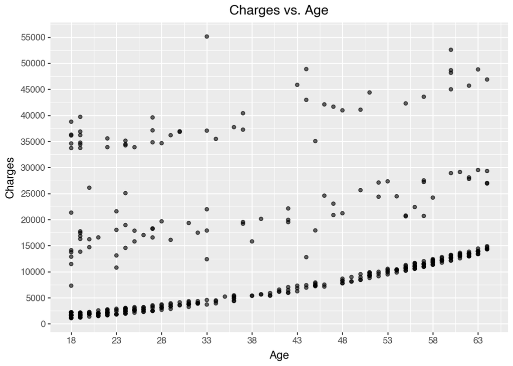

```python
from plotnine import *

(ggplot(myDataDummies, aes(x="age", y="charges"))
 + geom_point(alpha=0.6)
 + labs(title="Charges vs. Age",
        x="Age",
        y="Charges")
 + scale_x_continuous(
       limits=(myDataDummies["age"].min(), myDataDummies["age"].max()),
       breaks=range(int(myDataDummies["age"].min()),
                    int(myDataDummies["age"].max()) + 1, 5))
 + scale_y_continuous(
       limits=(myDataDummies["charges"].min(), myDataDummies["charges"].max()),
       breaks=range(0, int(myDataDummies["charges"].max()) + 1, 5000)))
```

The scatterplot shows that insurance charges tend to increase with age. Older individuals generally have higher charges, while younger people have lower costs. This suggests that age is an important factor in determining insurance expenses.

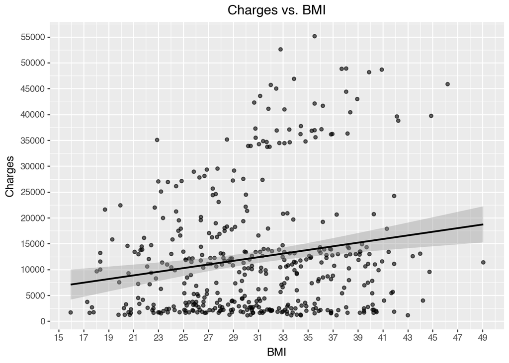

```python
(ggplot(myDataDummies, aes(x="bmi", y="charges"))
 + geom_point(alpha=0.6)
 + geom_smooth(method="lm", color="black")
 + labs(title="Charges vs. BMI",
        x="BMI",
        y="Charges")
 + scale_x_continuous(
       limits=(myDataDummies["bmi"].min(), myDataDummies["bmi"].max()),
       breaks=range(int(myDataDummies["bmi"].min()),
                    int(myDataDummies["bmi"].max()) + 1, 2))
 + scale_y_continuous(
       limits=(myDataDummies["charges"].min(), myDataDummies["charges"].max()),
       breaks=range(0, int(myDataDummies["charges"].max()) + 1, 5000)))
```

The scatterplot shows a positive relationship between BMI and insurance charges. People with higher BMI tend to have higher charges, although there is a lot of variance. This suggests that BMI may be related to insurance costs, but other factors could play a role too.

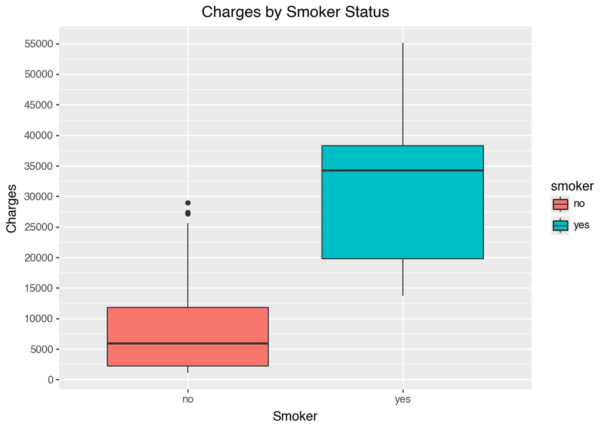

```python
(ggplot(myData, aes(x="smoker", y="charges", fill="smoker"))
 + geom_boxplot()
 + labs(title="Charges by Smoker Status",
        x="Smoker",
        y="Charges")
 + scale_y_continuous(
       limits=(myDataDummies["charges"].min(), myDataDummies["charges"].max()),
       breaks=range(0, int(myDataDummies["charges"].max()) + 1, 5000)))
```

The boxplot shows that smokers have much higher insurance charges than non-smokers. Their costs also vary more, while non-smokers usually have lower and more consistent charges. This suggests smoking greatly increases insurance costs.

## Part Two: Simple Linear Models

```python
from sklearn.linear_model import LinearRegression

X1 = myDataDummies[["age"]]
y1 = myDataDummies["charges"]

model1 = LinearRegression()
model1.fit(X1, y1)

print("Intercept:", model1.intercept_)
print("Slope:", model1.coef_)
print("R-squared:", model1.score(X1, y1))
```

```
Intercept: 3611.758798507093
Slope: [228.79904937]
R-squared: 0.09938105452062695
```

The model shows that insurance charges increase by about 228.80 for each additional year of age. The intercept of 3,611.76 represents the estimated charge when age is zero. The R squared value of 0.0994 means that the model explains about 9.94% of the variation in insurance charges. This shows that age has some effect on the charges, but other factors are also important in predicting charges.

```python
X2 = myDataDummies[["age", "sex_male"]]
y2 = myDataDummies["charges"]

model2 = LinearRegression()
model2.fit(X2, y2)

print("Intercept:", model2.intercept_)
print("Slope:", model2.coef_)
print("R-squared:", model2.score(X2, y2))
```

```
Intercept: 3315.3323465342473
Slope: [228.42586236 649.83258997]
R-squared: 0.10012952499706418
```

The model shows that insurance charges increase by about 228.43 for each additional year of age, and being male adds about 649.83 to the predicted charges. The intercept of 3,315.33 represents the estimated charge when age and the male variable are both zero. The R squared value of 0.1001 means the model explains about 10.01% of the variation in insurance charges. This shows that age and sex have some effect on the charges, but other factors are still important in predicting charges.

```python
X3 = myDataDummies[["age", "smoker"]]
y3 = myDataDummies["charges"]

model3 = LinearRegression()
model3.fit(X3, y3)

print("Intercept:", model3.intercept_)
print("Slope:", model3.coef_)
print("R-squared:", model3.score(X3, y3))
```

```
Intercept: -2166.852295375442
Slope: [  253.14535549 24048.86743795]
R-squared: 0.7603842948069405
```

The model shows that insurance charges increase by about 253.15 for each additional year of age. Being a smoker adds about 24,048.87 to the predicted charges compared to non-smokers. The intercept of –2,166.85 represents the estimated charge when age and the smoker variable are both zero. The R squared value of 0.7604 means the model explains about 76.04% of the variation in insurance charges. This shows that age and smoking status together provide a strong model for predicting variation in insurance charges.

```python
from sklearn.metrics import mean_squared_error

y2_pred = model2.predict(X2)

mse2 = mean_squared_error(y2, y2_pred)
r2_2 = model2.score(X2, y2)

print("Intercept:", model2.intercept_)
print("Slope:", model2.coef_)
print("R-squared:", r2_2)
print("MSE:", mse2)

y3_pred = model3.predict(X3)

mse3 = mean_squared_error(y3, y3_pred)
r2_3 = model3.score(X3, y3)

print("Intercept:", model3.intercept_)
print("Slope:", model3.coef_)
print("R-squared:", r2_3)
print("MSE:", mse3)
```

```
Intercept: 3315.3323465342473
Slope: [228.42586236 649.83258997]
R-squared: 0.10012952499706418
MSE: 126633939.67937085
Intercept: -2166.852295375442
Slope: [  253.14535549 24048.86743795]
R-squared: 0.7603842948069405
MSE: 33719831.46524372
```

## Part Three: Multiple Linear Models

```python
y1_pred = model1.predict(X1)

mse1 = mean_squared_error(y1, y1_pred)
r2_1 = model1.score(X1, y1)

print("Intercept:", model1.intercept_)
print("Slope:", model1.coef_)
print("R-squared:", r2_1)
print("MSE:", mse1)

X4 = myDataDummies[["age", "bmi"]]
y4 = myDataDummies["charges"]

model4 = LinearRegression()
model4.fit(X4, y4)

y4_pred = model4.predict(X4)

mse4 = mean_squared_error(y4, y4_pred)
r2_4 = model4.score(X4, y4)

print("Intercept:", model4.intercept_)
print("Slope:", model4.coef_)
print("R-squared:", r2_4)
print("MSE:", mse4)
```

```
Intercept: 3611.758798507093
Slope: [228.79904937]
R-squared: 0.09938105452062695
MSE: 126739267.9102639
Intercept: -4627.533445708497
Slope: [216.29721472 283.20380126]
R-squared: 0.12032144234129338
MSE: 123792439.58129103
```

The model with age and BMI has an intercept of –4627.53, with slopes of 216.30 for age and 283.20 for BMI. Its R squared is 0.12032, and the MSE is 123,792,439.58. Compared to the age only model (R squared 0.09938, MSE 126,739,267.91), it fits slightly better and predicts a little more accurately.

```python
print("Intercept:", model1.intercept_)
print("Slope:", model1.coef_)
print("R-squared:", r2_1)
print("MSE:", mse1)

myDataDummies["age_sq"] = myDataDummies["age"] ** 2

X5 = myDataDummies[["age", "age_sq"]]
y5 = myDataDummies["charges"]

model5 = LinearRegression()
model5.fit(X5, y5)

y5_pred = model5.predict(X5)

mse5 = mean_squared_error(y5, y5_pred)
r2_5 = model5.score(X5, y5)

print("Intercept:", model5.intercept_)
print("Slope:", model5.coef_)
print("R-squared:", r2_5)
print("MSE:", mse5)
```

```
Intercept: 3611.758798507093
Slope: [228.79904937]
R-squared: 0.09938105452062695
MSE: 126739267.9102639
Intercept: 2299.730568726638
Slope: [308.42816984  -1.00150889]
R-squared: 0.09958694669946933
MSE: 126710293.80956802
```

The model with age and age squared has an R squared of 0.09959 and an MSE of 126,710,293.81. These values are almost the same as the age-only model (R squared 0.09938, MSE 126,739,267.91). This means adding age squared does not improve the model.

```python
print("Intercept:", model1.intercept_)
print("Slope:", model1.coef_)
print("R-squared:", r2_1)
print("MSE:", mse1)

myDataDummies["age_cube"] = myDataDummies["age"] ** 3
myDataDummies["age_4"] = myDataDummies["age"] ** 4

X_poly4 = myDataDummies[["age", "age_sq", "age_cube", "age_4"]]
y_poly4 = myDataDummies["charges"]

model_poly4 = LinearRegression()
model_poly4.fit(X_poly4, y_poly4)

y_poly4_pred = model_poly4.predict(X_poly4)
mse_poly4 = mean_squared_error(y_poly4, y_poly4_pred)
r2_poly4 = model_poly4.score(X_poly4, y_poly4)

print("Intercept:", model_poly4.intercept_)
print("Coefficients:", model_poly4.coef_)
print("R-squared:", r2_poly4)
print("MSE:", mse_poly4)
```

```
Intercept: 3611.758798507093
Slope: [228.79904937]
R-squared: 0.09938105452062695
MSE: 126739267.9102639
Intercept: 68637.89783236325
Coefficients: [-7.94841022e+03  3.58110163e+02 -6.47905090e+00  4.12933982e-02]
R-squared: 0.10782931453183786
MSE: 125550389.64569828
```

```python
print("Intercept:", model1.intercept_)
print("Slope:", model1.coef_)
print("R-squared:", r2_1)
print("MSE:", mse1)

myDataDummies["age_5"] = myDataDummies["age"] ** 5
myDataDummies["age_6"] = myDataDummies["age"] ** 6
myDataDummies["age_7"] = myDataDummies["age"] ** 7
myDataDummies["age_8"] = myDataDummies["age"] ** 8
myDataDummies["age_9"] = myDataDummies["age"] ** 9
myDataDummies["age_10"] = myDataDummies["age"] ** 10
myDataDummies["age_11"] = myDataDummies["age"] ** 11
myDataDummies["age_12"] = myDataDummies["age"] ** 12

X12 = myDataDummies[[
    "age", "age_sq", "age_cube", "age_4", "age_5", "age_6",
    "age_7", "age_8", "age_9", "age_10", "age_11", "age_12"
]]
y12 = myDataDummies["charges"]

model12 = LinearRegression()
model12.fit(X12, y12)

y12_pred = model12.predict(X12)
mse12 = mean_squared_error(y12, y12_pred)
r2_12 = model12.score(X12, y12)

print("Intercept:", model12.intercept_)
print("Coefficients:", model12.coef_)
print("R-squared:", r2_12)
print("MSE:", mse12)
```

```
Intercept: 3611.758798507093
Slope: [228.79904937]
R-squared: 0.09938105452062695
MSE: 126739267.9102639
Intercept: 7452.28232594397
Coefficients: [ 3.04916864e-12  1.05406037e-10  3.49790534e-09  7.56584415e-08
  1.26243848e-06  1.25112288e-05 -2.08398111e-08 -1.85914310e-08
  4.09818395e-10 -2.52044310e-12 -1.01992192e-17  1.42766013e-16]
R-squared: 0.10908947739025832
MSE: 125373053.69365598
```

The polynomial model of degree 12 has an R squared of 0.10909 and an MSE of 125,373,053.69. Compared to the age-only model (R squared 0.09938, MSE 126,739,267.91), the polynomial model fits only slightly better and predicts a little more accurately.

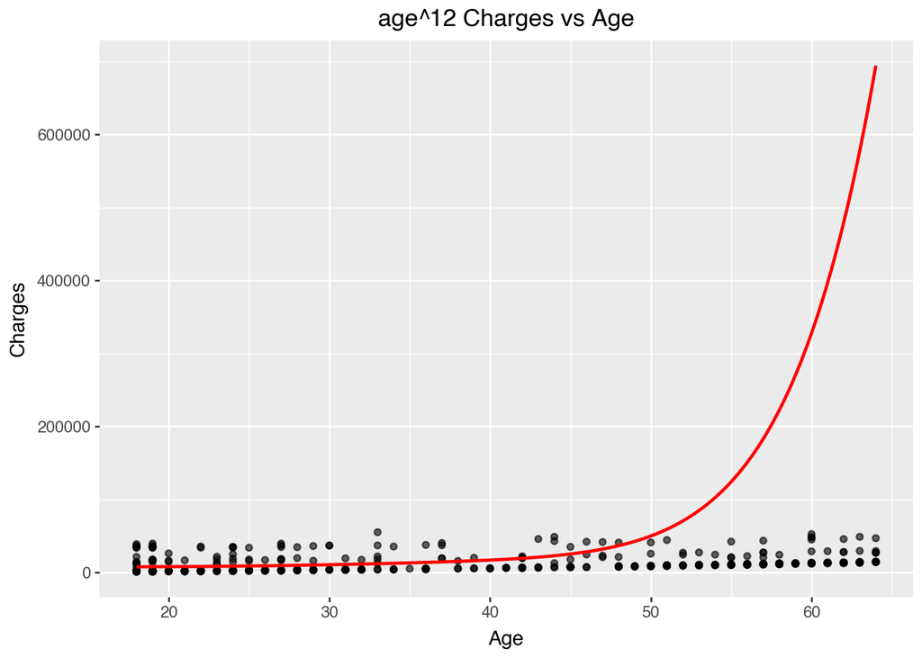

```python
import numpy as np

age_range = np.linspace(myDataDummies["age"].min(), myDataDummies["age"].max(), 300)
pred_data = pd.DataFrame({"age": age_range})
pred_data["age_sq"] = pred_data["age"] ** 2
pred_data["age_cube"] = pred_data["age"] ** 3
pred_data["age_4"] = pred_data["age"] ** 4
pred_data["age_5"] = pred_data["age"] ** 5
pred_data["age_6"] = pred_data["age"] ** 6
pred_data["age_7"] = pred_data["age"] ** 7
pred_data["age_8"] = pred_data["age"] ** 8
pred_data["age_9"] = pred_data["age"] ** 9
pred_data["age_10"] = pred_data["age"] ** 10
pred_data["age_11"] = pred_data["age"] ** 11
pred_data["age_12"] = pred_data["age"] ** 12

pred_data["predicted_charges"] = model12.predict(pred_data[[
    "age", "age_sq", "age_cube", "age_4", "age_5", "age_6",
    "age_7", "age_8", "age_9", "age_10", "age_11", "age_12"
]])

(ggplot(myDataDummies, aes(x="age", y="charges"))
 + geom_point(alpha=0.6)
 + geom_line(pred_data, aes(x="age", y="predicted_charges"), color="red", size=1)
 + labs(title="age^12 Charges vs Age",
        x="Age",
        y="Charges"))
```

## Part Four: New data

```python
myData2 = pd.read_csv("https://www.dropbox.com/s/sky86agc4s8c6qe/insurance_costs_2.csv?dl=1")

myData2.head()
```

|  | age | sex | bmi | smoker | region | charges |
| --- | --- | --- | --- | --- | --- | --- |
| 0 | 23 | male | 34.400 | no | southwest | 1826.84300 |
| 1 | 56 | male | 40.300 | no | southwest | 10602.38500 |
| 2 | 18 | male | 34.100 | no | southeast | 1137.01100 |
| 3 | 63 | female | 23.085 | no | northeast | 14451.83515 |
| 4 | 63 | male | 28.310 | no | northwest | 13770.09790 |

```python
myDataDummies2 = pd.get_dummies(myData2, columns = ["region", "sex"], drop_first=True)
cols = ["region_northwest", "region_southeast", "region_southwest", "sex_male"]
myDataDummies2[cols] = myDataDummies2[cols].astype(int)
myDataDummies2["smoker"] = myDataDummies2["smoker"].map({"yes": 1, "no": 0})

myDataDummies2 = myDataDummies2.dropna()

myDataDummies2.head()
```

|  | age | bmi | smoker | charges | region_northwest | region_southeast | region_southwest | sex_male |
| --- | --- | --- | --- | --- | --- | --- | --- | --- |
| 0 | 23 | 34.400 | 0 | 1826.84300 | 0 | 0 | 1 | 1 |
| 1 | 56 | 40.300 | 0 | 10602.38500 | 0 | 0 | 1 | 1 |
| 2 | 18 | 34.100 | 0 | 1137.01100 | 0 | 1 | 0 | 1 |
| 3 | 63 | 23.085 | 0 | 14451.83515 | 0 | 0 | 0 | 0 |
| 4 | 63 | 28.310 | 0 | 13770.09790 | 1 | 0 | 0 | 1 |

```python
y = myDataDummies2["charges"]

X1 = myDataDummies2[["age"]]
model1 = LinearRegression().fit(X1, y)
mse1 = mean_squared_error(y, model1.predict(X1))

X2 = myDataDummies2[["age", "bmi"]]
model2 = LinearRegression().fit(X2, y)
mse2 = mean_squared_error(y, model2.predict(X2))

X3 = myDataDummies2[["age", "bmi", "smoker"]]
model3 = LinearRegression().fit(X3, y)
mse3 = mean_squared_error(y, model3.predict(X3))

myDataDummies2["age_smoker"] = myDataDummies2["age"] * myDataDummies2["smoker"]
myDataDummies2["bmi_smoker"] = myDataDummies2["bmi"] * myDataDummies2["smoker"]

X4 = myDataDummies2[["age", "bmi", "age_smoker", "bmi_smoker"]]
model4 = LinearRegression().fit(X4, y)
mse4 = mean_squared_error(y, model4.predict(X4))

X5 = myDataDummies2[["age", "bmi", "smoker", "age_smoker", "bmi_smoker"]]
model5 = LinearRegression().fit(X5, y)
mse5 = mean_squared_error(y, model5.predict(X5))

print(f"(age): MSE = {mse1}")
print(f"(age + bmi): MSE = {mse2}")
print(f"(age + bmi + smoker): MSE = {mse3}")
print(f"((age + bmi):smoker): MSE = {mse4}")
print(f"((age + bmi)*smoker): MSE = {mse5}")

print(f"((age + bmi)*smoker) have be best MSE of {mse5}")
```

```
(age): MSE = 135675408.50904146
(age + bmi): MSE = 131898602.87106094
(age + bmi + smoker): MSE = 33869793.93014486
((age + bmi):smoker): MSE = 23506154.92401845
((age + bmi)*smoker): MSE = 20781196.187022757
((age + bmi)*smoker) have be best MSE of 20781196.187022757
```

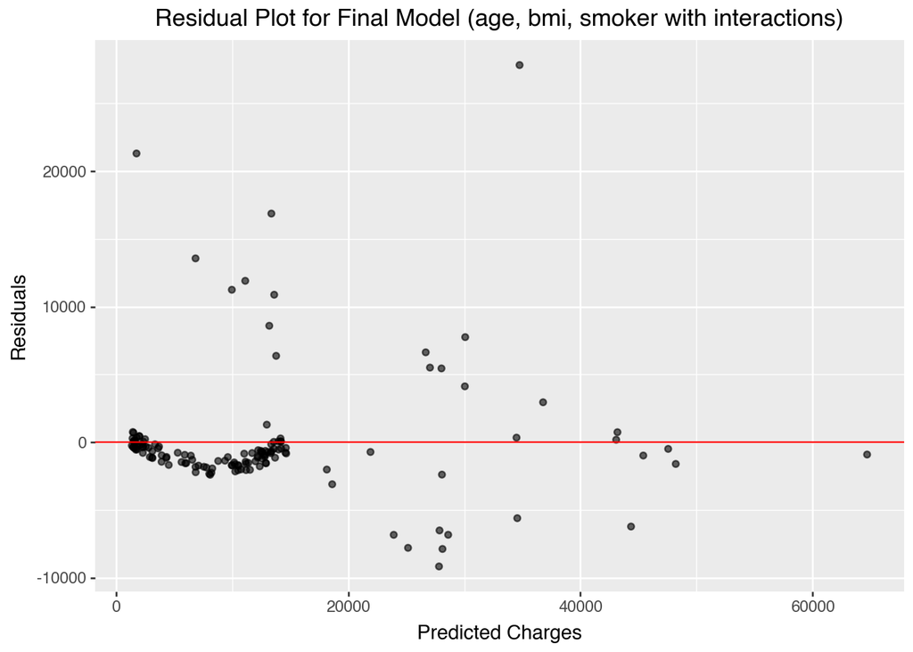

```python
myDataDummies2["predicted"] = model5.predict(X5)
myDataDummies2["residuals"] = myDataDummies2["charges"] - myDataDummies2["predicted"]

(ggplot(myDataDummies2, aes(x="predicted", y="residuals"))
 + geom_point(alpha=0.6)
 + geom_hline(yintercept=0, color="red")
 + labs(title="Residual Plot for Final Model (age, bmi, smoker with interactions)",
        x="Predicted Charges",
        y="Residuals"))
```

## Part Five: Full Exploration

```python
from sklearn.model_selection import train_test_split

train, test = train_test_split(myDataDummies2, test_size=0.2, random_state=42)

y_train = train["charges"]
y_test = test["charges"]

train["age_bmi"] = train["age"] * train["bmi"]
test["age_bmi"] = test["age"] * test["bmi"]

X_train_best = train[["age", "bmi", "smoker", "age_bmi", "bmi_smoker"]]
X_test_best = test[["age", "bmi", "smoker", "age_bmi", "bmi_smoker"]]

model_best = LinearRegression().fit(X_train_best, y_train)
mse_best = mean_squared_error(y_test, model_best.predict(X_test_best))

print(mse_best)
```

```
18745527.399801344
```

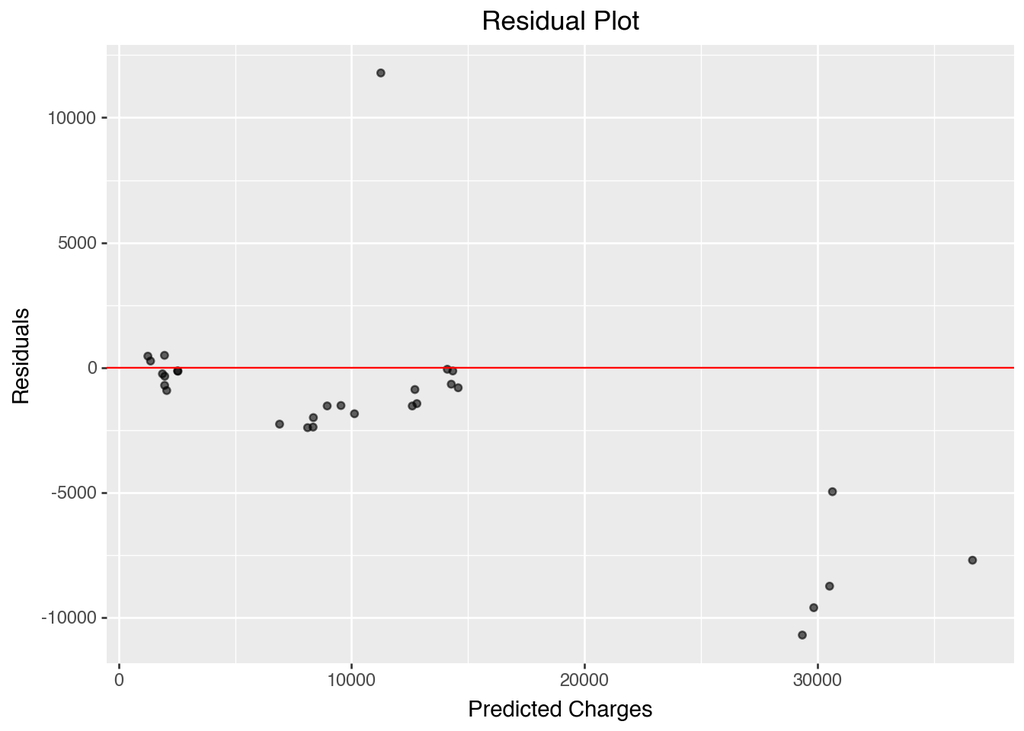

```python
test["predicted"] = model_best.predict(X_test_best)
test["residuals"] = y_test - test["predicted"]

(ggplot(test, aes(x="predicted", y="residuals"))
 + geom_point(alpha=0.6)
 + geom_hline(yintercept=0, color="red")
 + labs(title="Residual Plot",
        x="Predicted Charges", y="Residuals"))
```